# Predicting Biceps Curl Form Based on Accelerometer Data

butchie

September 23, 2015

### Executive Summary

A predictive model was constructed to determine what type of biceps curl form, to be called curl class in this analysis, was being used by six individuals asked to perform five different curling motions. By sacrificing generality, a high-performing model was constructed for each individual based on a training dataset. Through the use of classification trees and boosting, accuracies ranging from 91.3% to 99.4% were obtained on validation dataset. Additionally, prediction 100% accuracy was achieved by the models on a small set of test data.

### Exploratory Data Analysis

The dataset consisted of the accelerometer measurements attached to six subjects while performing five different biceps curl motions, categorized by the letters ‘A’ through ‘E.’ A total of 19622 observations were made among the 30 combinations of subject and curling motion, with 153 accelerometer measurements listed for each observation. Measurements containing NAs blank values were then removed along with six columns that did not consist of accelerometer data. After transformation, the data consisted of the subject names as well as 53 accelerometer measurements.  
To get a better understanding of the data, a scatterplot of two accelerometer measurements, pitch_belt and roll_belt, was constructed as shown in Figure 1. The measurements for each type of curl performed all appear in three different clusters. A second set of scatterplots, one for each test subject, was made and shown in Figure 2. These plots show each individual’s curling data for the same accelerometers on the same scale as the first figure. Based on the relative tightness of each subject’s data, it is apparent that individual differences in form are the cause of the three clusters in the first and not an unknown global cause.

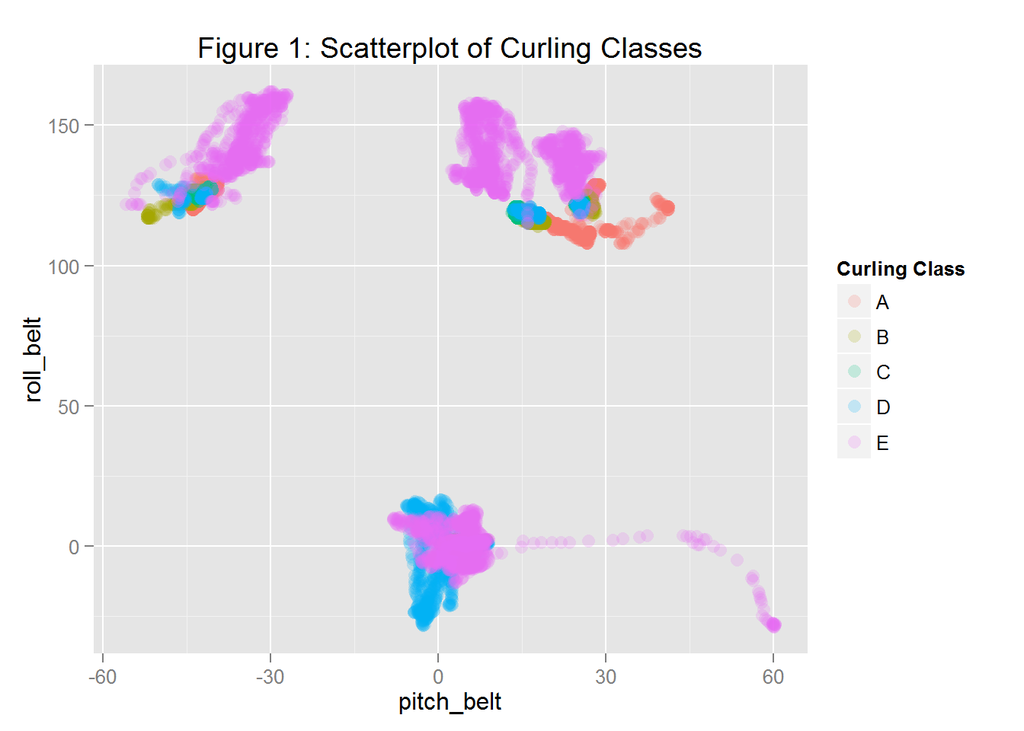

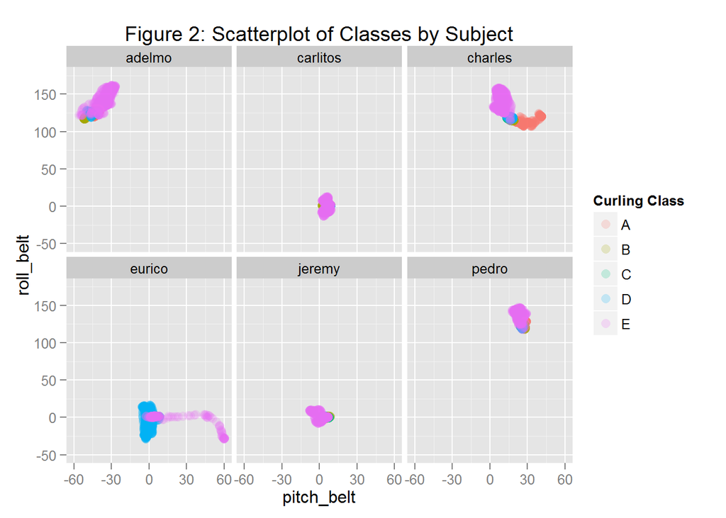

### Analysis Methods

The observation made in the previous section allowed for simplification of the analysis. Because the measurements appeared to be affected more by the test subject’s form rather than the type of curl being performed, it was possible to simplify the problem by constructing predictive models for each individual. The simpler could be constructed substantially faster than an overarching one. Even with this simplification, more computationally demanding techniques such as random forests or boosting required further simplification in the dataset due to there being 53 accelerometer measurements for each of several thousand observations for each subject.  
Each subject’s data was randomly partitioned by curl class into a training and validation set with a 60/40 ratio. Classification trees were then formed on the training data. The accuracy of the trees was relatively low, ranging from 64.5% for Pedro to 78.3% for Eurico. While this method alone could not be used as a good model, a list of the most important accelerometer measurements with respect to prediction was generated for each subject’s data. The length of this list ranged from 6 for Pedro to 14 for Eurico. More sophisticated techniques were then employed only on these measurements. Boosting using the default parameters through the caret and gbm packages of R was performed on the reduced datasets to try to improve the results of each model.

### Cross Validation Results

```
##    Subject Training Accuracy Validation Accuracy
## 1   Adelmo         1.0000000           0.9884319
## 2 Carlitos         1.0000000           0.9742558
## 3  Charles         1.0000000           0.9936261
## 4   Eurico         1.0000000           0.9885714
## 5   Jeremy         1.0000000           0.9793662
## 6    Pedro         0.9764031           0.9126679
```

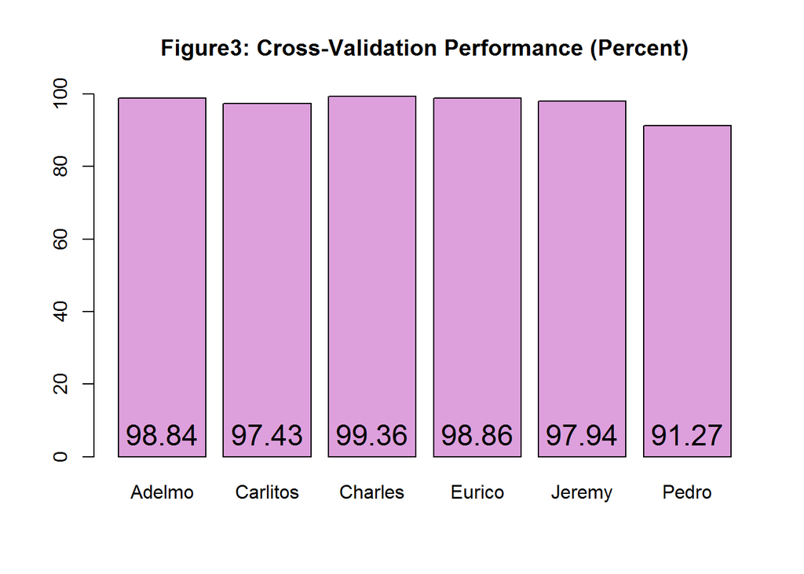

Lastly, the models were used to predict the curling class on a small test set of data, consisting of 20 observations. 100% prediction accuracy was obtained, where the small sample size aided the accuracy in this case.

### Conclusions

The process of individualizing models for curl class prediction and making use of classification trees and boosting resulted in high cross-validated prediction accuracies ranging for 91.3% to 99.4%. It should be noted that such individualization could only be performed under certain conditions and would not generalize well. The test set included information about which subject was performing the curl to be measured. Without this knowledge, such models could not be used and if attmepted, would not be accurate. Additionally, such models could not generalize to prediction of curling class for any individual. Instead, an overarching model would be needed and would likely require data from a larger population of individuals.

## Appendix

Performance measures of classification trees for each subject as well as confusion matrices of the cross-validation are included below:

### Adelmo

```
##          cp  Accuracy     Kappa AccuracySD    KappaSD
## 1 0.1178986 0.6458020 0.5329674 0.05767728 0.08553016
## 2 0.1612706 0.5987380 0.4630291 0.06955393 0.10633947
## 3 0.2327428 0.3865495 0.1375285 0.08150705 0.12478676
```

```
##
## boostpredAd   A   B   C   D   E
##           A 465   2   0   0   0
##           B   0 306   2   0   0
##           C   1   2 290   2   0
##           D   0   0   8 203   0
##           E   0   0   0   1 274
```

### Carlitos

```
##          cp  Accuracy     Kappa AccuracySD    KappaSD
## 1 0.1125731 0.6828425 0.6020739 0.04997919 0.06440105
## 2 0.1461988 0.5995811 0.4937904 0.08410359 0.10970661
## 3 0.1853070 0.4226098 0.2450965 0.10483903 0.16143710
```

```
##
## boostpredCa   A   B   C   D   E
##           A 324   0   0   4   0
##           B   4 267   4   0   0
##           C   0   7 193   2   4
##           D   5   0   0 188   0
##           E   0   2   0   0 239
```

### Charles

```
##          cp  Accuracy     Kappa AccuracySD   KappaSD
## 1 0.2285354 0.6911974 0.6060536 0.09825219 0.1292743
## 2 0.2417929 0.5634961 0.4356303 0.08774380 0.1232162
## 3 0.2676768 0.3377772 0.1199393 0.10688025 0.1381570
```

```
##
## boostpredCh   A   B   C   D   E
##           A 359   1   0   0   0
##           B   0 297   2   0   0
##           C   0   0 212   2   0
##           D   0   0   1 252   1
##           E   0   0   0   2 283
```

### Eurico

```
##           cp  Accuracy     Kappa AccuracySD    KappaSD
## 1 0.03016591 0.7825676 0.7266171 0.02423074 0.02972164
## 2 0.06108597 0.7495350 0.6862649 0.02633147 0.03208984
## 3 0.15837104 0.6950993 0.6152941 0.09582526 0.13874974
```

```
##
## boostpredEu   A   B   C   D   E
##           A 342   1   0   0   0
##           B   2 235   5   0   0
##           C   0   0 190   1   0
##           D   0   0   0 228   0
##           E   2   0   0   3 216
```

### Jeremy

```
##           cp  Accuracy     Kappa AccuracySD    KappaSD
## 1 0.09715994 0.6997418 0.6084443 0.03339707 0.04381085
## 2 0.12892377 0.5963613 0.4685777 0.05838271 0.07959284
## 3 0.25635277 0.4351289 0.1929661 0.08169593 0.17475413
```

```
##
## boostpredJe   A   B   C   D   E
##           A 468   0   0   0   0
##           B   2 183   3   0   1
##           C   0  10 251   4   0
##           D   0   0   6 204   0
##           E   0   2   0   0 223
```

### Pedro

```
##          cp  Accuracy     Kappa AccuracySD    KappaSD
## 1 0.1241554 0.6446794 0.5535345 0.06187168 0.07775203
## 2 0.1722973 0.5338162 0.4068675 0.06161435 0.08850077
## 3 0.2423986 0.3175709 0.1076795 0.10065129 0.12430071
```

```
##
## boostpredPe   A   B   C   D   E
##           A 239   9   1   1   0
##           B  14 178   3   6   2
##           C   3  11 179  20   0
##           D   0   4  16 159   0
##           E   0   0   0   1 196
```